# **7. Evaluate on Test set**

### Question 1

For regular season dataset, we ran the test data against the 5 models. For model logistic regression we see that the models trained on “Distance” and “Distance and Angle” have better performance. The roc_auc score has increased for both from 0.68 to 0.70. But for model trained on “Angle” we see that the model is not performing as good as it did while building models. We see the similar effect on other graph as well.

For XGBoost model, we see that is slight decrease in performance than while building it. The roc_auc score has decreased from 0.76 to 0.74. Other than that reliability graph is also moved away from perfected collaborated line. Hence we can say that there are some performance decrease during test.

For Weighted Random Forest, we see that the performance of the test is same as the performance when we were building the file. We see that the curves and all other matrices are very similar.

We expected the model to perform better or the same for all the test sets but we see that there is no huge change in performance but slight increase or decrease as mentioned above.

### Curves for Regular season test set

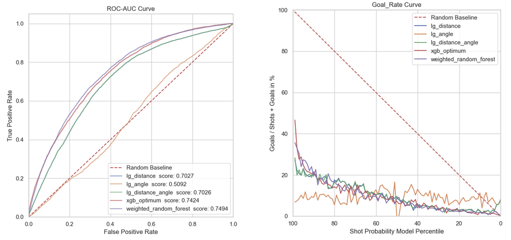

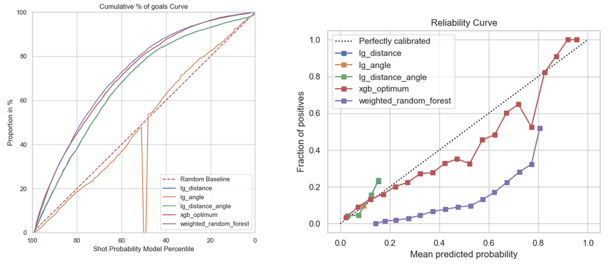

### Question 2

For testing our models with the playoffs season test dataset. We see that all the models are not performing we as it did for the regular season test dataset. We see that all the roc_auc scores for all the models are less than the regular season or even when we build it. In terms of recall, we see that it’s the same as for the logistic regression models and XGBoost models but we see a decrease in recall for weighted random forest compared to while we trained.

We see some difference in the playoffs test dataset compared to the regular season dataset. First, we see that there are 8 periods in playoffs all of 20 mins each expect the last period which ends as soon as the team scores. Second, when we were doing the one-hot encoding we see that the we don’t have 2 features which we had in the regular season.

- last event type goal
- and last event type penatly

### Curves for Playoffs season test set

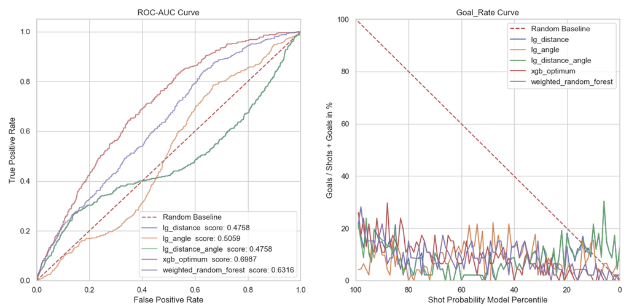

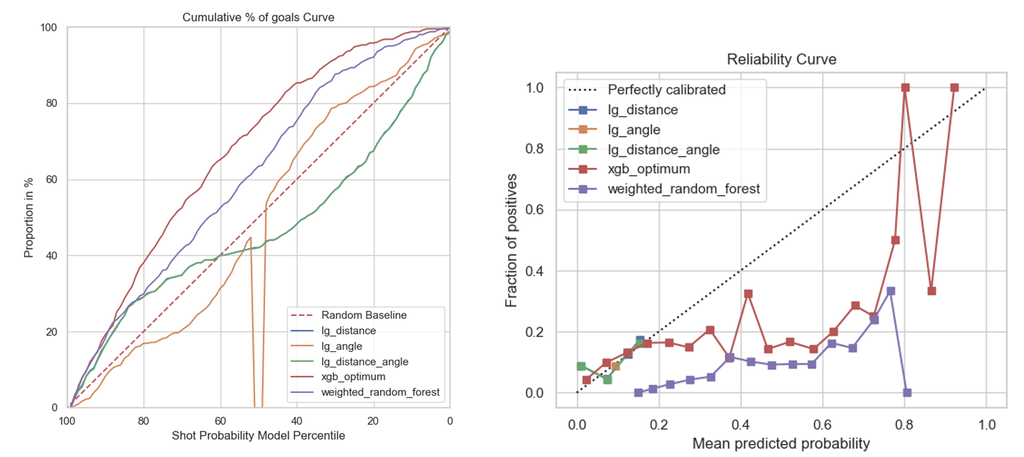